# Beyond the P-Value: Visualizing and Embracing Uncertainty

```r
library(infer)
```

## P-value: Living in the world of the null hypothesis

I tried to bend a quarter to make it “unfair” and yield tails more often. Did I succeed?

$$H_0: p = 0.5$$
$$H_A: p < 0.5$$

Let’s say I flip it 5 times and got heads only once. How unusual is that under the null hypothesis? We can easily simulate this in R using the `infer` package:

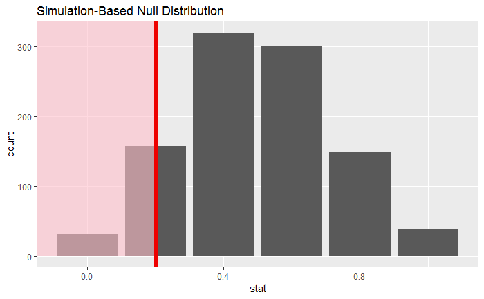

| p_value |
| --- |
| 0.19 |

## Experiment 1 data

`exp1.xlsx` contains 100 subjects who took the ESP test (tried to guess which curtain the picture was behind). During each session, some of the pictures were erotic and some were non-erotic.

Variables are as follows:

- *Session* Order in which participant was seen.
- *Session_Type* (Added EB) Some participants saw different combinations of stimuli. This is my best guess from Bem’s writing about which was which.
- *Num_Erotic* (Added EB) Number of erotic trials, varies by session type; my best guess.
- *Num_Control* (Added EB) Number of control trials, varies by session type; my best guess.
- *Erotic.Hits.PC* Percentage correct on erotic trials
- *Control.Hits.PC* Percentage correct on control trials
- *Stimulus.Seeking* 1-5 scale on how “stimulus-seeking” the participant is
- *Date*
- *StartTime*
- *Session.Length*
- *Participant.Sex*
- *Participant.Age*
- *ExpSex* ?

Below is code for reading in all trials, calculating the overall hit rate, and testing whether it is significantly different from chance:

$$H_0 = \mu_\text{hit rate} = 50$$
$$H_A = \mu_\text{hit rate} > 50$$
What did we actually see on average?

| stat |
| --- |
| 51.06944 |

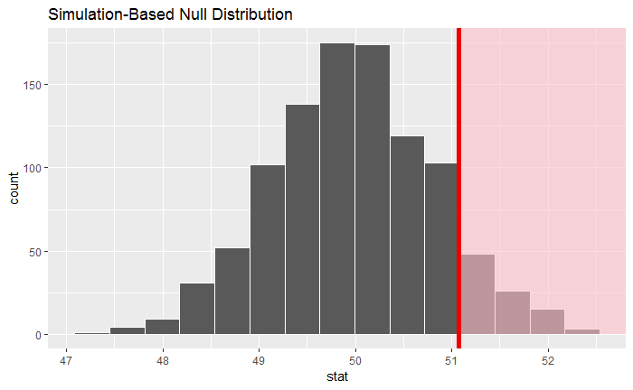

| p_value |
| --- |
| 0.094 |

We can also do a good old-fashioned t-test, for a similar result:

```r
t.test(exp1_all_hits$All.Hits.PC, mu = 50, alternative = "greater")
```

```
    One Sample t-test

data:  exp1_all_hits$All.Hits.PC
t = 1.2884, df = 99, p-value = 0.1003
alternative hypothesis: true mean is greater than 50
95 percent confidence interval:
 49.69124      Inf
sample estimates:
mean of x
 51.06944
```

Can you find any significant findings here?

## Preregistration

- Preregister on Open Science

## Visual hypothesis testing – the line-up